# R Notebook

# Load the housing_prices.csv data set and undertake an initial exploration of the data. You will find details on the data set on the relevant Kaggle page

```r
housing_prices <- read_csv("4_diamonds_hw/data/housing_prices.csv") %>%
  clean_names()
```

# We expect the total_rooms of houses to be strongly correlated with total_bedrooms. Use ggpairs() to investigate correlations between these two variables.

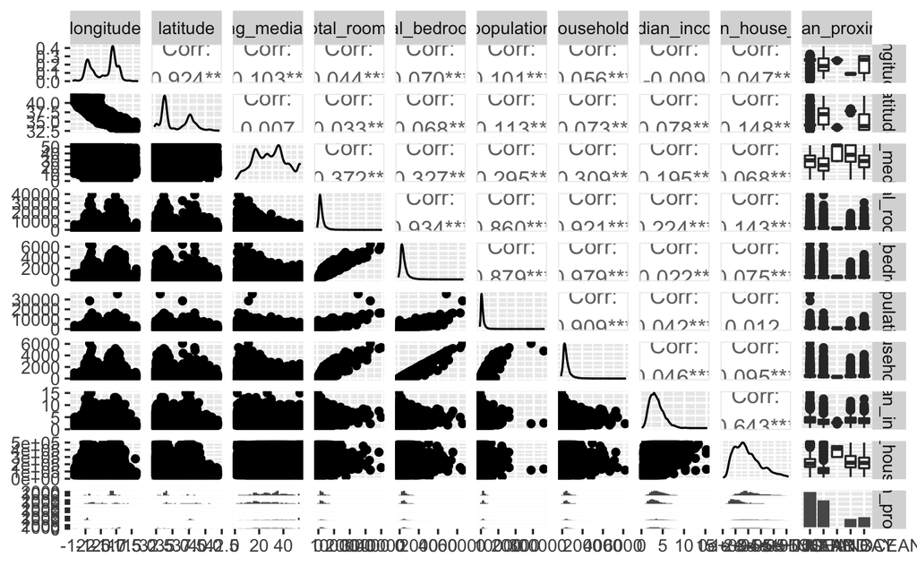

```r
housing_prices %>%
  ggpairs()
```

# So, we do find significant correlations. Let’s drop total_bedrooms from the dataset, and use only total_rooms going forward.

```r
housing_prices_clean <- housing_prices %>%
  select(-total_bedrooms)
```

# We are interested in developing a regression model for the median_house_value of a house in terms of the possible predictor variables in the dataset.

## Use ggpairs() to investigate correlations between median_house_value and the predictors (this may take a while to run, don’t worry, make coffee or something).

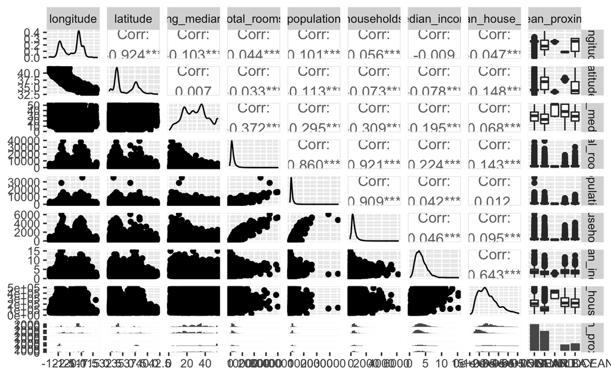

```r
housing_prices_clean %>%
  ggpairs()
```

```r
# median_income has a strong correlation and total_rooms has a small positive correlatin, and latitude has a small negative correlation
```

## Perform further ggplot visualisations of any significant correlations you find.

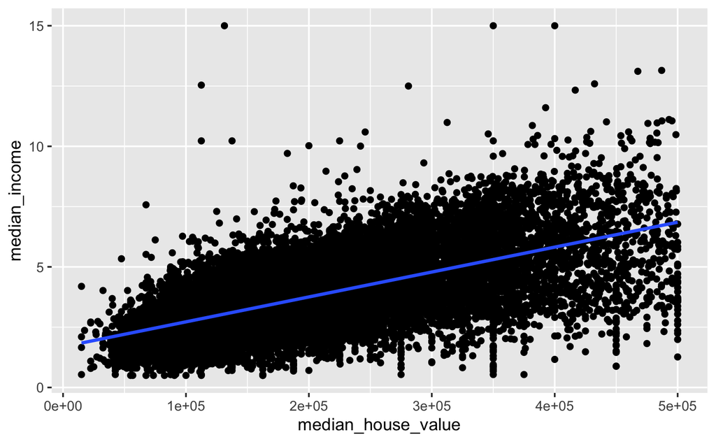

```r
housing_prices %>%
  ggplot(aes(median_house_value, median_income)) +
  geom_point() +
  geom_smooth(method = "lm")
```

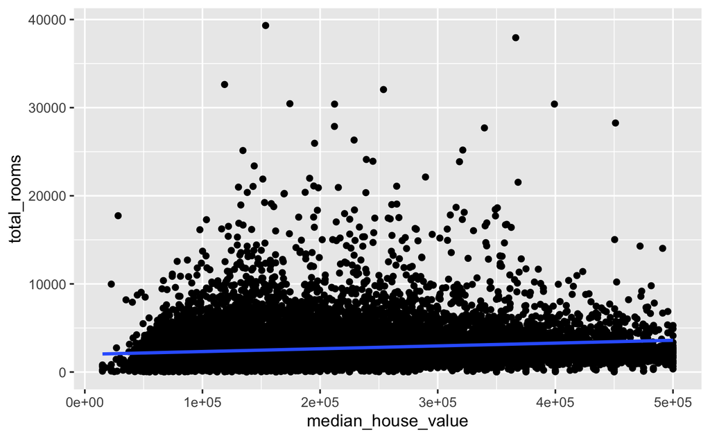

```r
housing_prices %>%
  ggplot(aes(median_house_value, total_rooms)) +
  geom_point() +
  geom_smooth(method = "lm")
```

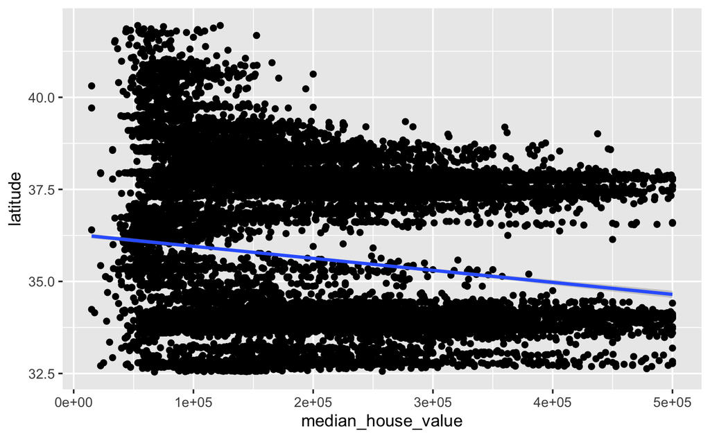

```r
housing_prices %>%
  ggplot(aes(median_house_value, latitude)) +
  geom_point() +
  geom_smooth(method = "lm")
```